# R Notebook

## PD model Moneyflow

The plan of the analysis:

1. Environment setup, familiarizing myself with data
2. Data cleaning and exploration - missing values, vaiable types, distributions
3. Exploring relationships of variables with the default rate
4. Setup an XGBoost model, find hyperparameters, check number of variables in the model
5. Fit final model, explore results

### Setup and first look at data

First glance at data

```r
dim(invoices)
```

```
[1] 9321   21
```

```r
glimpse(invoices)
```

```
Rows: 9,321
Columns: 21
$ invoice_id                    <chr> "cf734ddd3a7331fa03622e45152a5d99018d7eea", "cea607655aa2f2b2a830e10845f4de775996d0ee", "8f8a3f32126d69adbf1c0f4880d…
$ invoice_amount                <dbl> 11625.00, 11975.00, 16875.00, 16875.00, 30687.50, 21500.00, 26562.50, 13056.25, 15106.25, 11150.00, 7562.50, 10225.5…
$ seller_is_public              <lgl> FALSE, FALSE, FALSE, FALSE, FALSE, FALSE, FALSE, FALSE, FALSE, FALSE, FALSE, FALSE, FALSE, FALSE, FALSE, FALSE, FALS…
$ seller_main_industry_code     <chr> "5bab61eb53176449e25c2c82f172b82cb13ffb9d", "5bab61eb53176449e25c2c82f172b82cb13ffb9d", "5bab61eb53176449e25c2c82f17…
$ seller_company_type           <chr> "e8382524c550b426d32c02de508b211f9844a6bb", "e8382524c550b426d32c02de508b211f9844a6bb", "e8382524c550b426d32c02de508…
$ seller_danish_pep             <lgl> FALSE, FALSE, FALSE, FALSE, FALSE, FALSE, FALSE, FALSE, FALSE, FALSE, FALSE, FALSE, FALSE, FALSE, FALSE, FALSE, FALS…
$ seller_risika_score           <dbl> 7, 7, 7, 7, 5, 5, 5, 0, 0, 0, 5, 4, 1, 7, 0, 7, 0, 0, 0, 5, 5, 4, 5, 5, 5, 4, 4, 4, 4, 0, 0, 0, 0, 0, 1, 4, 4, 1, 4,…
$ payer_is_public               <chr> "FALSE", "FALSE", "FALSE", "FALSE", "FALSE", "FALSE", "FALSE", "FALSE", "FALSE", "FALSE", "FALSE", "FALSE", "FALSE",…
$ payer_main_industry_code      <chr> "5bab61eb53176449e25c2c82f172b82cb13ffb9d", "5bab61eb53176449e25c2c82f172b82cb13ffb9d", "5bab61eb53176449e25c2c82f17…
$ payer_company_type            <chr> "e8382524c550b426d32c02de508b211f9844a6bb", "e8382524c550b426d32c02de508b211f9844a6bb", "e8382524c550b426d32c02de508…
$ payer_danish_pep              <lgl> FALSE, FALSE, FALSE, FALSE, FALSE, FALSE, FALSE, FALSE, FALSE, FALSE, FALSE, FALSE, FALSE, FALSE, FALSE, FALSE, FALS…
$ payer_eu_sanctions            <lgl> FALSE, FALSE, FALSE, FALSE, FALSE, FALSE, FALSE, FALSE, FALSE, FALSE, FALSE, FALSE, FALSE, FALSE, FALSE, FALSE, FALS…
$ payer_risika_score            <chr> "6.0", "5.0", "5.0", "5.0", "5.0", "6.0", "6.0", "10.0", "10.0", "10.0", "8.0", "4.0", "9.0", "4.0", "8.0", "9.0", "…
$ offer_cost_percent            <dbl> 4.67, 4.00, 4.67, 4.67, 4.67, 4.00, 4.00, 4.67, 4.67, 4.67, 4.01, 4.01, 4.00, 4.00, 4.00, 4.00, 4.00, 4.00, 4.01, 4.…
$ offer_seller_is_first_invoice <chr> "?", "?", "?", "?", "?", "?", "?", "?", "?", "?", "?", "?", "?", "?", "?", "?", "?", "?", "?", "?", "?", "?", "?", "…
$ inv_iss2due                   <dbl> 4, 0, 4, 3, 0, 0, 0, 0, 0, 0, 0, 0, 0, 0, 0, 0, 0, 0, 0, 0, 0, 0, 0, 0, 0, 0, 0, 0, 0, 0, 0, 20, 0, 0, 8, 0, 0, 8, 0…
$ inv_iss2purch                 <dbl> 4, 0, 4, 3, 0, 0, 0, 0, 0, 0, 0, 0, 0, 0, 0, 0, 0, 0, 0, 0, 0, 0, 0, 0, 0, 0, 0, 0, 0, 0, 0, 4, 0, 0, 0, 0, 0, 0, 0,…
$ inv_due2today                 <dbl> 662, 662, 662, 662, 659, 648, 648, 637, 637, 637, 636, 634, 633, 633, 624, 624, 623, 620, 620, 619, 619, 619, 619, 6…
$ seller_age                    <dbl> 1, 1, 1, 1, 1, 1, 1, 2, 2, 2, 1, 9, 1, 10, 3, 5, 3, 3, 3, 14, 5, 16, 5, 5, 5, 16, 16, 16, 16, 3, 2, 2, 3, 3, 4, 4, 4…
$ payerr_age                    <chr> "1.0", "1.0", "1.0", "1.0", "1.0", "1.0", "1.0", "1.0", "1.0", "1.0", "1.0", "15.0", "1.0", "11.0", "34.0", "2021.0"…
$ defaulted                     <chr> "n", "n", "n", "n", "n", "n", "n", "n", "n", "n", "y", "n", "n", "n", "n", "n", "n", "n", "n", "n", "n", "n", "n", "…
```

### Cleaning and exploration

```r
table(invoices$defaulted, useNA = 'ifany')
```

```
   n    y
8854  467
```

```r
table(invoices$seller_is_public, useNA = 'ifany')
```

```
FALSE  <NA>
 9309    12
```

```r
table(invoices$seller_is_public, invoices$defaulted, useNA = 'ifany') # remove
```

```
           n    y
  FALSE 8842  467
  <NA>    12    0
```

```r
table(invoices$seller_danish_pep, useNA = 'ifany')
```

```
FALSE  TRUE
 7287  2034
```

```r
table(invoices$payer_is_public, useNA = 'ifany')
```

```
    ? FALSE  TRUE
   61  9099   161
```

```r
table(invoices$payer_danish_pep, useNA = 'ifany')
```

```
FALSE  TRUE
 4343  4978
```

```r
table(invoices$payer_eu_sanctions, useNA = 'ifany') # remove
```

```
FALSE
 9321
```

```r
table(invoices$offer_seller_is_first_invoice, useNA = 'ifany')
```

```
    ? FALSE  TRUE
  506  8432   383
```

```r
nrow(table(invoices$seller_main_industry_code))
```

```
[1] 186
```

```r
nrow(table(invoices$seller_company_type))
```

```
[1] 7
```

```r
nrow(table(invoices$payer_main_industry_code))
```

```
[1] 346
```

```r
nrow(table(invoices$payer_company_type))
```

```
[1] 24
```

```r
table(invoices$seller_company_type)
```

```
26fa7b4824a1620ff6c26cc79004218bb6633e22 39425b7f4c7ddc431fa028a1e7fcfac86e942fc6 5512eedf485857092a0855af37f42e38c9951540
                                     149                                      141                                     1277
5bab61eb53176449e25c2c82f172b82cb13ffb9d b358b1323c4b0515cef36c2276b0af32ed580381 cc23395a745ff03be62ca521c618d99990acfb36
                                      12                                        1                                       20
e8382524c550b426d32c02de508b211f9844a6bb
                                    7721
```

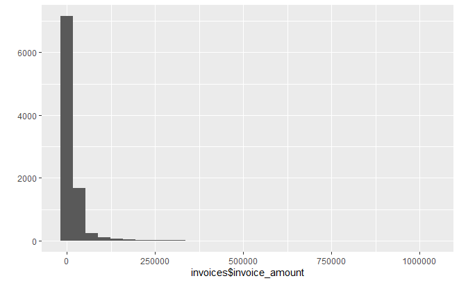

```r
qplot(invoices$invoice_amount)
```

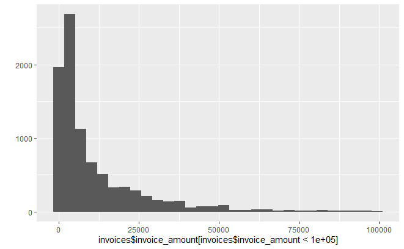

```r
qplot(invoices$invoice_amount[invoices$invoice_amount<100000])
```

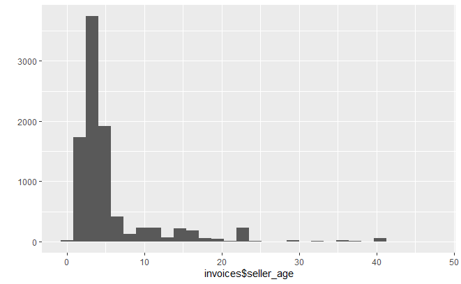

```r
qplot(invoices$seller_age)
```

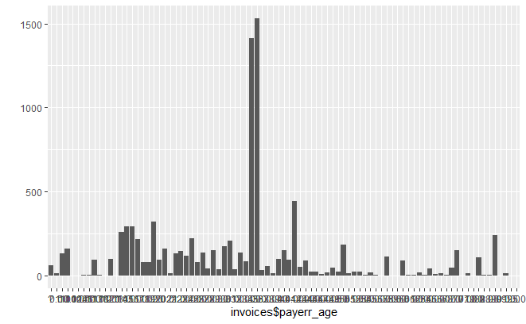

```r
qplot(invoices$payerr_age)
```

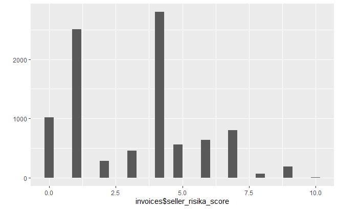

```r
qplot(invoices$seller_risika_score)
```

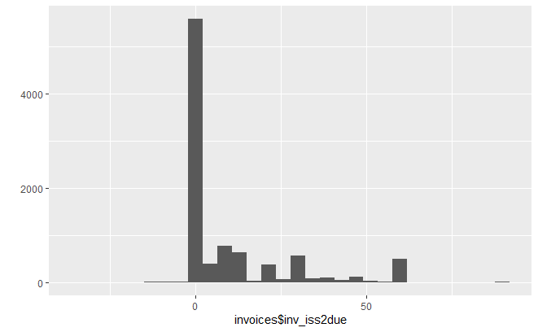

```r
qplot(invoices$inv_iss2due)
```

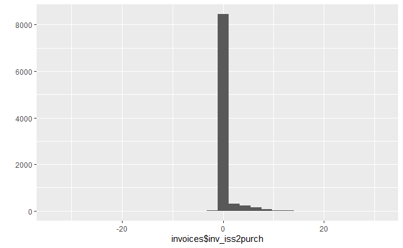

```r
qplot(invoices$inv_iss2purch)
```

Takeaways:

```r
seller_industry_size <- invoices %>%
  group_by(seller_main_industry_code) %>%
  summarise(seller_ind_size = n()/nrow(invoices)) %>%
  select(seller_main_industry_code, seller_ind_size)

seller_company_size <- invoices %>%
  group_by(seller_company_type) %>%
  summarise(seller_comp_size = n()/nrow(invoices)) %>%
  select(seller_company_type, seller_comp_size)

payer_industry_size <- invoices %>%
  group_by(payer_main_industry_code) %>%
  summarise(payer_ind_size = n()/nrow(invoices)) %>%
  select(payer_main_industry_code, payer_ind_size)

payer_company_size <- invoices %>%
  group_by(payer_company_type) %>%
  summarise(payer_comp_size = n()/nrow(invoices)) %>%
  select(payer_company_type, payer_comp_size)

colnames(invoices)
```

```
 [1] "invoice_id"                    "invoice_amount"                "seller_is_public"              "seller_main_industry_code"
 [5] "seller_company_type"           "seller_danish_pep"             "seller_risika_score"           "payer_is_public"
 [9] "payer_main_industry_code"      "payer_company_type"            "payer_danish_pep"              "payer_eu_sanctions"
[13] "payer_risika_score"            "offer_cost_percent"            "offer_seller_is_first_invoice" "inv_iss2due"
[17] "inv_iss2purch"                 "inv_due2today"                 "seller_age"                    "payerr_age"
[21] "defaulted"
```

```r
invoices_clean <- invoices %>%
  select(- invoice_id,
         - seller_is_public, #since there are only 12 observations which are all missing
         - payer_eu_sanctions) %>%
  mutate(
    response = case_when(defaulted == 'y' ~ 1, T ~ 0),
    seller_danish_pep_num = as.numeric(seller_danish_pep),
    payer_is_public_num = case_when(payer_is_public == "FALSE" ~ 0,
                                    payer_is_public == "TRUE" ~ 1,
                                    T ~ NA_real_),
    payer_danish_pep_num = as.numeric(payer_danish_pep),

    payer_risika_score_num = suppressWarnings(as.numeric(payer_risika_score)),

    offer_seller_is_first_invoice_num = case_when(offer_seller_is_first_invoice == "FALSE" ~ 0,
                                    offer_seller_is_first_invoice == "TRUE" ~ 1,
                                    T ~ NA_real_),
    payer_age_num = suppressWarnings(case_when(as.numeric(payerr_age) == 2021 ~ 1,
                                               T ~ as.numeric(payerr_age))), # assuming 2021 is an error
    seller_age_num = as.numeric(seller_age),
    invoice_issue_date = today() - days(inv_due2today),
    invoice_issue_yearmonth = paste0(year(invoice_issue_date),
                                     case_when(
                                       nchar(month(invoice_issue_date)) == 1 ~ paste0('0',month(invoice_issue_date)),
                                       T ~ as.character(month(invoice_issue_date)))),
    seller_payer_company_type_match = case_when(seller_company_type == payer_company_type ~ 1, T ~ 0),
    seller_payer_industry_type_match = case_when(seller_main_industry_code == payer_main_industry_code ~ 1, T ~ 0)) %>%

  left_join(seller_industry_size, by = 'seller_main_industry_code') %>%
  left_join(seller_company_size, by = 'seller_company_type') %>%
  left_join(payer_industry_size, by = 'payer_main_industry_code') %>%
  left_join(payer_company_size, by = 'payer_company_type') %>%

  mutate(payer_comp_type_f = case_when(payer_comp_size >0.50 ~'Large',
                                            payer_comp_size > 0.1 ~ 'Medium',
                                            T ~ 'Small'),
         seller_comp_type_f = case_when(seller_comp_size >0.50 ~'Large',
                                       seller_comp_size > 0.1 ~ 'Medium',
                                           T ~ 'Small'),
         payer_industry_size_f = case_when(payer_ind_size >0.1 ~'Large',
                                           payer_ind_size > 0.01 ~ 'Medium',
                                           T ~ 'Small'),
         seller_industry_size_f = case_when(seller_ind_size >0.07 ~'Large',
                                       seller_ind_size > 0.01 ~ 'Medium',
                                       T ~ 'Small'),
         ) %>%
filter(inv_due2today <= 360)
```

#### Stability in time

Assuming that today() - (inv_due2today) gives us an estimate of invoice issue date, I will check whether badrate and distribution are stable in time.

```r
invoices_clean %>%
  group_by(invoice_issue_yearmonth) %>%
  summarise(nn = n(),
            br = mean(response))
```

| invoice_issue_yearmonth | nn | br |
| --- | --- | --- |
| 202110 | 372 | 0.01344086 |
| 202111 | 706 | 0.05524079 |
| 202112 | 846 | 0.04491726 |
| 202201 | 925 | 0.03351351 |
| 202202 | 1106 | 0.05696203 |
| 202203 | 1119 | 0.03038427 |
| 202204 | 1299 | 0.03233256 |
| 202205 | 235 | 0.02978723 |

#### Distributions of cleaned inputs

```
click left mouse button to proceed
```

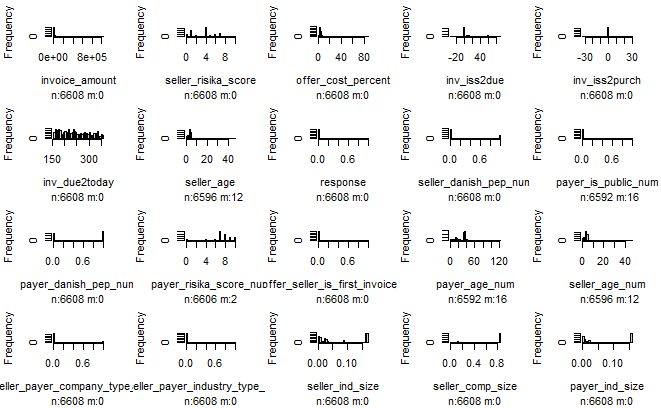

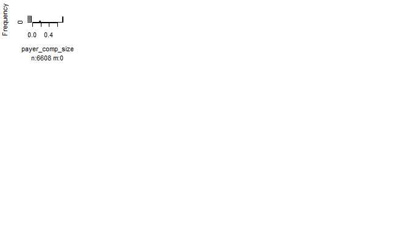

```r
hist.data.frame(invoices_clean %>% select_if(is.numeric), n.unique =  2)
```

We can see that distributions are right-skewed for some variables like invoice_amount, offer_cost_percent, seller_age, payer_age. XGBoost is robust to outliers, so no transformations will be made to data because of the distribution.

### Relationship between variables and response

#### Information Value

I will be using Information Value IV) to evaluate how each variable relates to response. Features with very low (sub and close to 0.05) IV will be excluded from the model.

create_infotables output consists of two parts - Tables and Summary. Tables provides detailed IV and WOE evaluation for each variable, while Summary gives an overview for each feature.

```r
infvalue <- create_infotables(data=invoices_clean, y="response", bins=10, parallel=FALSE)
```

```
[1] "Variable invoice_issue_date was removed because it is a Date variable"
```

```r
infvalue$Summary
```

|  | Variable | IV |
| --- | --- | --- |
| 7 | payer_main_industry_code | 2.7183501526 |
| 2 | seller_main_industry_code | 2.2211093534 |
| 17 | payerr_age | 1.9903600682 |
| 24 | payer_age_num | 1.1268098739 |
| 31 | payer_ind_size | 0.9676857911 |
| 29 | seller_ind_size | 0.8886974202 |
| 35 | payer_industry_size_f | 0.7591532749 |
| 11 | offer_cost_percent | 0.7002628451 |
| 1 | invoice_amount | 0.5955129703 |
| 13 | inv_iss2due | 0.4607501087 |

[output cut: 26 more lines]

```r
infvalue$Tables$payer_age_num
```

| payer_age_num | N | Percent | WOE | IV |
| --- | --- | --- | --- | --- |
| NA | 16 | 0.002421308 | 3.1992245 | 0.09478659 |
| [0,5] | 597 | 0.090345036 | 0.7394539 | 0.16491593 |
| [6,12] | 597 | 0.090345036 | -0.4591957 | 0.18041512 |
| [13,16] | 758 | 0.114709443 | -0.4089870 | 0.19637327 |
| [17,23] | 560 | 0.084745763 | 0.7373074 | 0.26170720 |
| [24,33] | 703 | 0.106386199 | 1.0591584 | 0.45939230 |
| [34,34] | 1174 | 0.177663438 | -2.4792401 | 0.87797970 |
| [35,38] | 1501 | 0.227148910 | -1.3965685 | 1.12396785 |
| [39,121] | 702 | 0.106234867 | 0.1576827 | 1.12680987 |

```r
infvalue$Tables$payer_ind_size
```

| payer_ind_size | N | Percent | WOE | IV |
| --- | --- | --- | --- | --- |
| [0,0] | 623 | 0.094279661 | 0.06540396 | 0.0004156778 |
| [0,0] | 682 | 0.103208232 | 0.15470210 | 0.0030696367 |
| [0,0.01] | 671 | 0.101543584 | 0.10193206 | 0.0041756838 |
| [0.01,0.01] | 635 | 0.096095642 | 1.14261103 | 0.2204912571 |
| [0.01,0.02] | 610 | 0.092312349 | 0.56891617 | 0.2595648438 |
| [0.02,0.04] | 715 | 0.108202179 | 0.23247980 | 0.2660816372 |
| [0.04,0.04] | 53 | 0.008020581 | 1.31649329 | 0.2921242331 |
| [0.16,0.16] | 1236 | 0.187046005 | -2.53087525 | 0.7441443503 |
| [0.16,0.16] | 1383 | 0.209291768 | -1.38355396 | 0.9676857911 |

```r
infvalue$Tables$seller_ind_size
```

| seller_ind_size | N | Percent | WOE | IV |
| --- | --- | --- | --- | --- |
| [0,0] | 655 | 0.09912228 | 0.9588526 | 0.1438281 |
| [0,0.01] | 632 | 0.09564165 | -0.4514337 | 0.1597398 |
| [0.01,0.02] | 691 | 0.10457022 | 0.1066681 | 0.1609899 |
| [0.02,0.02] | 628 | 0.09503632 | 0.2068312 | 0.1654661 |
| [0.02,0.03] | 653 | 0.09881961 | -0.9643351 | 0.2258969 |
| [0.03,0.09] | 611 | 0.09246368 | 1.5194058 | 0.6658276 |
| [0.16,0.16] | 1381 | 0.20898910 | -1.3820920 | 0.8886974 |
| [0.17,0.17] | 1357 | 0.20535714 | 0.0000000 | 0.8886974 |

- Another suspiciously high IV for offer_cost_percent. This could be because offer is made after evaluating credit risk of the invoice, thus providing some sort of target leak. Without knowing the business specifics however, it is hard to know at this point. It could also be that invoice price is agreed on in the contract with the business and doesn’t change from invoice to invoice.
- Some variables that will be discarded at this step:
  - offer_seller_is_first_invoice_num
  - inv_iss2purch
  - payer_danish_pep_num
  - seller_payer_company_type_match

#### Correlations

Check correlations between variables, to help in later steps when selecting features for the model.

```r
cormatrix <- cor(invoices_clean %>% select_if(is.numeric), use = 'pairwise.complete.obs')

round(cormatrix,2)
```

```
                                  invoice_amount seller_risika_score offer_cost_percent inv_iss2due inv_iss2purch inv_due2today seller_age response
invoice_amount                              1.00               -0.17              -0.09       -0.04         -0.04          0.07       0.01     0.05
seller_risika_score                        -0.17                1.00               0.13        0.09         -0.01         -0.16       0.21    -0.04
offer_cost_percent                         -0.09                0.13               1.00        0.13         -0.03          0.03      -0.06     0.00
inv_iss2due                                -0.04                0.09               0.13        1.00          0.04         -0.18      -0.03    -0.07
inv_iss2purch                              -0.04               -0.01              -0.03        0.04          1.00          0.09       0.01    -0.04
inv_due2today                               0.07               -0.16               0.03       -0.18          0.09          1.00       0.09     0.01
seller_age                                  0.01                0.21              -0.06       -0.03          0.01          0.09       1.00     0.04
response                                    0.05               -0.04               0.00       -0.07         -0.04          0.01       0.04     1.00
seller_danish_pep_num                      -0.08                0.16              -0.07       -0.07          0.25          0.08       0.12    -0.05
payer_is_public_num                         0.05                0.00              -0.04        0.01         -0.02          0.08       0.10    -0.01
payer_danish_pep_num                       -0.10                0.32               0.18        0.13          0.04         -0.05      -0.13    -0.04
payer_risika_score_num                     -0.06                0.00               0.02        0.01          0.11          0.08      -0.01    -0.02
offer_seller_is_first_invoice_num           0.06               -0.05              -0.13       -0.02         -0.03          0.07       0.05     0.01
payer_age_num                              -0.15                0.17               0.11        0.10          0.02          0.01      -0.06    -0.06
seller_age_num                              0.01                0.21              -0.06       -0.03          0.01          0.09       1.00     0.04
seller_payer_company_type_match             0.02               -0.17              -0.08       -0.02         -0.02         -0.04       0.03    -0.02
seller_payer_industry_type_match            0.10                0.04              -0.06       -0.02          0.01          0.07       0.07     0.04
seller_ind_size                            -0.23                0.47               0.23        0.14          0.09         -0.07      -0.11    -0.10
seller_comp_size                           -0.02                0.17               0.09        0.05          0.05         -0.05      -0.32     0.03
payer_ind_size                             -0.25                0.47               0.24        0.18          0.12         -0.13      -0.16    -0.13
payer_comp_size                            -0.02                0.17               0.12        0.07          0.07          0.07       0.01    -0.03
                                  seller_danish_pep_num payer_is_public_num payer_danish_pep_num payer_risika_score_num offer_seller_is_first_invoice_num
invoice_amount                                    -0.08                0.05                -0.10                  -0.06                              0.06
seller_risika_score                                0.16                0.00                 0.32                   0.00                             -0.05
offer_cost_percent                                -0.07               -0.04                 0.18                   0.02                             -0.13
inv_iss2due                                       -0.07                0.01                 0.13                   0.01                             -0.02
inv_iss2purch                                      0.25               -0.02                 0.04                   0.11                             -0.03
inv_due2today                                      0.08                0.08                -0.05                   0.08                              0.07
seller_age                                         0.12                0.10                -0.13                  -0.01                              0.05
response                                          -0.05               -0.01                -0.04                  -0.02                              0.01
seller_danish_pep_num                              1.00               -0.05                 0.21                   0.24                             -0.09
payer_is_public_num                               -0.05                1.00                -0.13                  -0.30                              0.02
payer_danish_pep_num                               0.21               -0.13                 1.00                   0.35                             -0.13
payer_risika_score_num                             0.24               -0.30                 0.35                   1.00                             -0.11
offer_seller_is_first_invoice_num                 -0.09                0.02                -0.13                  -0.11                              1.00
payer_age_num                                      0.09                0.04                 0.44                   0.28                             -0.11
seller_age_num                                     0.12                0.10                -0.13                  -0.01                              0.05
seller_payer_company_type_match                   -0.06               -0.04                -0.26                  -0.07                              0.05
seller_payer_industry_type_match                   0.07               -0.03                -0.19                  -0.03                              0.03
```

[output cut: 33 more lines]

```
seller_age                                   -0.32          -0.16            0.01
response                                      0.03          -0.13           -0.03
seller_danish_pep_num                         0.17           0.36            0.18
payer_is_public_num                           0.00          -0.09           -0.22
payer_danish_pep_num                          0.28           0.64            0.55
payer_risika_score_num                        0.16           0.22            0.53
offer_seller_is_first_invoice_num            -0.14          -0.15           -0.12
payer_age_num                                 0.22           0.44            0.39
seller_age_num                               -0.32          -0.16            0.01
seller_payer_company_type_match              -0.03          -0.32           -0.52
seller_payer_industry_type_match             -0.06          -0.17           -0.02
seller_ind_size                               0.42           0.88            0.52
seller_comp_size                              1.00           0.35            0.26
payer_ind_size                                0.35           1.00            0.50
payer_comp_size                               0.26           0.50            1.00
```

### Grid search

#### Parameter tuning

For this prediction task I will use XGBoost model - it is fast to fit, in my experience works well with binomial prediction problems, handles missing values well and is robust to outliers. Downside is that all features have to be numeric.

At this point I will split data into train and test data, tune hyperparameters of the model on train data using 3-fold CV and fit final model.

```r
initial_set_variables <- c(
  'payer_age_num',
  'payer_ind_size',
  'seller_ind_size',
  'offer_cost_percent',
  'payer_risika_score_num',
  'seller_age_num',
  'invoice_amount',
  'inv_due2today',
  'inv_iss2due',
  'seller_risika_score',
  'seller_danish_pep_num',
  'seller_comp_size',
  'payer_comp_size',

  'response'
)

set.seed(101) # Set Seed so that same sample can be reproduced in future also
# Now Selecting 75% of data as sample from total 'n' rows of the data
sample <- sample.int(n = nrow(invoices_clean), size = floor(.75*nrow(invoices_clean)), replace = F)
train_dat <- invoices_clean[sample, initial_set_variables]
test_dat  <- invoices_clean[-sample,initial_set_variables ]

mean(train_dat$response)
mean(test_dat$response)

xg <- XGBTrainer$new(early_stopping = 50,
                     objective = 'binary:logistic')
xgb_model_1 <- GridSearchCV$new(trainer = xg,
                                parameters = list(n_estimators = c(1500),
                                                  learning_rate = c(0.01, 0.1),
                                                  max_depth = c(5,2,10),
                                                  min_child_weight = c(5,10)),
                                n_folds = 3,
                                scoring = c('auc'))


xgb_model_1$fit(train_dat %>% select(initial_set_variables), "response")
```

| n_estimators | learning_rate | max_depth | min_child_weight | auc_avg | auc_sd |
| --- | --- | --- | --- | --- | --- |
| 1500 | 0.01 | 5 | 5 | 0.9414875 | 0.01323637 |
| 1500 | 0.10 | 5 | 5 | 0.9320316 | 0.01293407 |
| 1500 | 0.01 | 2 | 5 | 0.9267317 | 0.01827149 |
| 1500 | 0.10 | 2 | 5 | 0.9321285 | 0.01547750 |
| 1500 | 0.01 | 10 | 5 | 0.9403202 | 0.00920387 |
| 1500 | 0.10 | 10 | 5 | 0.9305993 | 0.01453422 |
| 1500 | 0.01 | 5 | 10 | 0.9424563 | 0.01136287 |
| 1500 | 0.10 | 5 | 10 | 0.9331800 | 0.01124068 |
| 1500 | 0.01 | 2 | 10 | 0.9302801 | 0.01229595 |
| 1500 | 0.10 | 2 | 10 | 0.9381902 | 0.01624949 |

[output cut: 2 more lines]

Looks like learning rate 0.01 is optimal, while max_depth and min_child_weight have very similar results irregardless of the value. I will take the parameters from the highest avg_test_AUC run-

- learning rate 0.01
- min_child_weight 10
- max_depth 5

Now that I have an idea about optimal parameters, I will perform another CV to see the optimal number of trees to build (nrounds parameter for xgboost). I will check at which nrounds test AUC begins to deteriorate

| iter | train_auc_mean | train_auc_std | test_auc_mean | test_auc_std |
| --- | --- | --- | --- | --- |
| 1977 | 0.9913518 | 0.0007791041 | 0.9353228 | 0.01835609 |
| 1978 | 0.9913568 | 0.0007795875 | 0.9353205 | 0.01835772 |
| 1976 | 0.9913462 | 0.0007860382 | 0.9353111 | 0.01835988 |
| 1975 | 0.9913424 | 0.0007810600 | 0.9353077 | 0.01839304 |
| 1973 | 0.9913343 | 0.0007862492 | 0.9353058 | 0.01841348 |
| 1972 | 0.9913337 | 0.0007918752 | 0.9353008 | 0.01840909 |
| 1971 | 0.9913230 | 0.0007854344 | 0.9353006 | 0.01842616 |
| 1970 | 0.9913206 | 0.0007817462 | 0.9352978 | 0.01840845 |
| 1979 | 0.9913618 | 0.0007724845 | 0.9352976 | 0.01836371 |
| 1984 | 0.9913881 | 0.0007569766 | 0.9352969 | 0.01836146 |

#### Initial model

I will fit the first model and check feature importance to see if there are more redundant features to remove.

| Feature | Gain | Cover | Frequency |
| --- | --- | --- | --- |
| seller_ind_size | 0.2392767976 | 0.3035671358 | 0.1662304543 |
| offer_cost_percent | 0.2323116834 | 0.1863500473 | 0.1655593584 |
| invoice_amount | 0.1900785202 | 0.1289894225 | 0.1919334273 |
| payer_age_num | 0.0852388257 | 0.1440429580 | 0.1323401114 |
| payer_ind_size | 0.0620169163 | 0.0752293086 | 0.1111334810 |
| seller_risika_score | 0.0473681460 | 0.0316785146 | 0.0583182337 |
| seller_age_num | 0.0444498702 | 0.0475004281 | 0.0638212201 |
| payer_risika_score_num | 0.0361701348 | 0.0352841278 | 0.0536876720 |
| inv_iss2due | 0.0323116314 | 0.0301459785 | 0.0310717402 |
| payer_comp_size | 0.0180766861 | 0.0060877958 | 0.0128850413 |

[output cut: 2 more lines]

Looks like some redundant features can be excluded:

- seller_danish_pep_num
- payer_comp_size
- seller_comp_size

I will exclude them and check hyperparameters again, and fit the final model.

### Final model

```r
adjusted_set_variables <- c(
  'payer_age_num',
  'payer_ind_size',
  'seller_ind_size',
  'offer_cost_percent',
  'payer_risika_score_num',
  'seller_age_num',
  'invoice_amount',
  # 'inv_due2today',
  'inv_iss2due',
  # 'seller_danish_pep_num',
  # 'seller_comp_size',
  # 'payer_comp_size',
  'seller_risika_score',

  'response'
)

xg2<- XGBTrainer$new(early_stopping = 50,
                     objective = 'binary:logistic')

xgb_model_2 <- GridSearchCV$new(trainer = xg2,
                                parameters = list(n_estimators = c(5000),
                                                  learning_rate = c(0.01, 0.1),
                                                  max_depth = c(5,2,10),
                                                  min_child_weight = c(5,10,20)),
                                n_folds = 3,
                                scoring = c('auc'))


xgb_model_2$fit(train_dat %>% select(adjusted_set_variables), "response")
```

[output not shown]

### Final model analysis

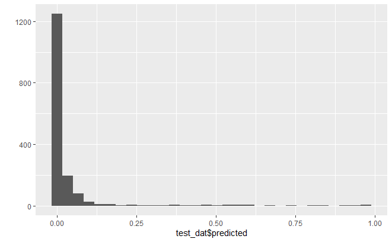

AUC on the test data is 0.9618.

It looks like there are some very high default rate invoices identified, however most of the predictions are centered around 1%.

I have been able to identify some very high risk invoices. Depending on business strategy I would guess that invoices with PD > 0.5 aren’t worth buying, invoices with PD 0.1-0.5 could be bought at a corresponding price and 0-0.1 can be worked with.

### Test data prediction

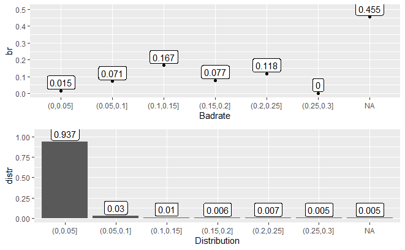

Further areas of exploration: